# Course 5 Project 1

Thomas Badon

## Introduction

This assignment answers questions about data from personal activity monitoring.

```r
library(ggplot2)
library(plyr)
activity <- read.csv("activity.csv")
```

### Process Data

```r
activity$day <- weekdays(as.Date(activity$date))
activity$DateTime<- as.POSIXct(activity$date, format="%Y-%m-%d")

##pulling data without nas
clean <- activity[!is.na(activity$steps),]
```

## What is the mean total number of steps taken in a day?

Number of steps

```r
Table <- aggregate(activity$steps ~ activity$date, FUN = sum, )
colnames(Table) <- c("Date", "Steps")
```

Historgram of steps

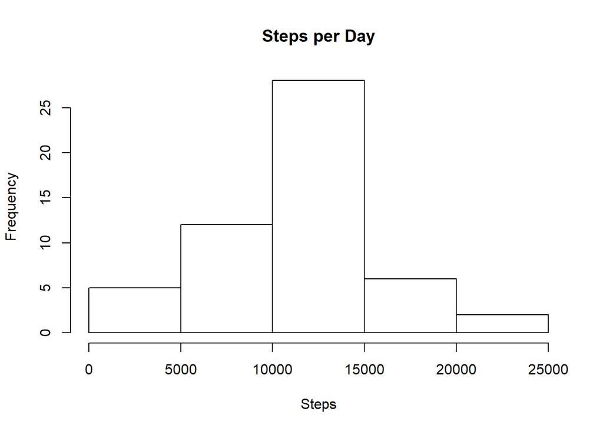

```r
hist(Table$Steps, breaks= 5, xlab = "Steps", main = "Steps per Day")
```

Mean and Median Steps per day

```r
#Mean steps
mean <- as.integer(mean(Table$Steps))

#Median Steps
median <- as.integer(median(Table$Steps))
```

The average number of steps taken each day was 10766. The median number of steps taken each day was 10765.

## Daily Activity Patterns

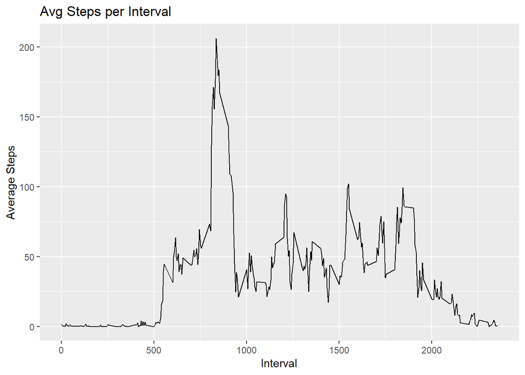

```r
## avg steps per interval
intTable <- ddply(clean, .(interval), summarize, Avg = mean(steps))

## line plot
p <- ggplot(intTable, aes(x=interval, y=Avg), xlab = "Interval", ylab = "Avg Steps")
p + geom_line() +xlab("Interval")+ylab("Average Steps")+ggtitle("Avg Steps per Interval")
```

```r
##Max steps
maxSteps <- max(intTable$Avg)

##which interval
maxInt <- intTable[intTable$Avg==maxSteps, 1]
```

## Imputing Missing Values

Calculate the total missing values in the dataset.

```r
## NAs in original

NAs <- nrow(activity[is.na(activity$steps),])
```

The total number of rows with missing values is 2304.

### Strategy for filling in missing values.

I will substitute missing values with median steps per 5 minute interval.

```r
## Median steps per interval table  per day
medTable <- ddply(clean, .(interval, day), summarize, Med = median(steps))

## dataset with missing values to substitute
Nadata <- activity[is.na(activity$steps),]

## merge
merged <- merge(Nadata, medTable, by = c("interval", "day"))
```

New Dataset with filled values

```r
## order columns
newdata <- merged[, c(6,4,1,2,5)]
colnames(newdata) <- c("steps","date", "interval", "day", "DateTime")

## merge again
mergeData <- rbind(clean, newdata)
```

Histogram of number of steps and calculate the new mean and median steps per day.

```r
Table2 <- aggregate(mergeData$steps ~ mergeData$date, FUN= sum, )

colnames(Table2) <- c("Date", "Steps")

## mean steps with NAs substituted
NAmean <- as.integer(mean(Table2$Steps))

## Median steps with NAs substituted
NAmedian <- as.integer(median(Table2$Steps))
```

Now a histogram

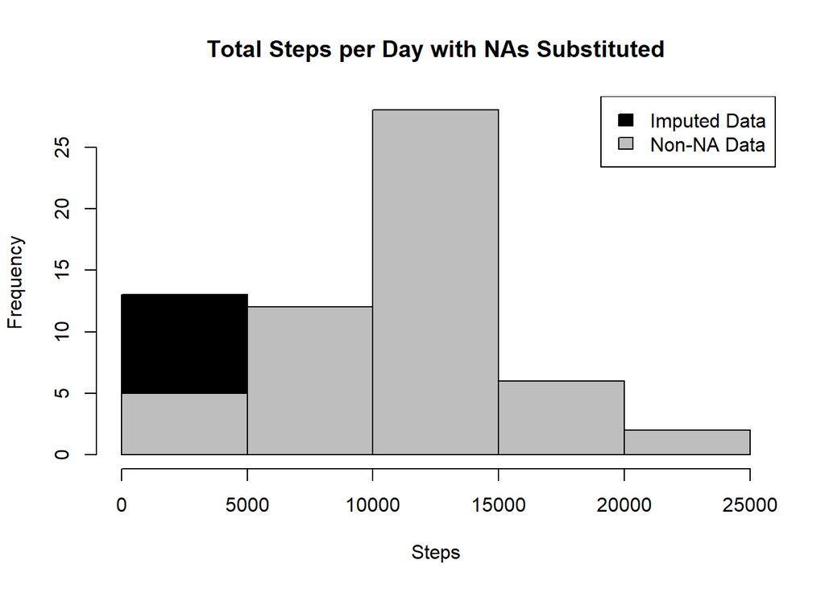

```r
hist(Table2$Steps, breaks=5, xlab="Steps", main = "Total Steps per Day with NAs Substituted", col="Black")
hist(Table$Steps, breaks=5, xlab="Steps", main = "Total Steps per Day with NAs Substituted", col="Grey", add=T)
legend("topright", c("Imputed Data", "Non-NA Data"), fill=c("black", "grey") )
```

The mean with NAs substituted by median values is 9705 compared to the previous mean of 10766.

The median with NAs substituted by median values is 10395 compared to the previous mean of 10765.

## Is there a difference in activity between weekdays and weekends?

Create weekday and weekend variables.

```r
## days of the week
mergeData$DayType <- ifelse(mergeData$day %in% c("Saturday", "Sunday"), "Weekend", "Weekday")
```

### Time Series Plot

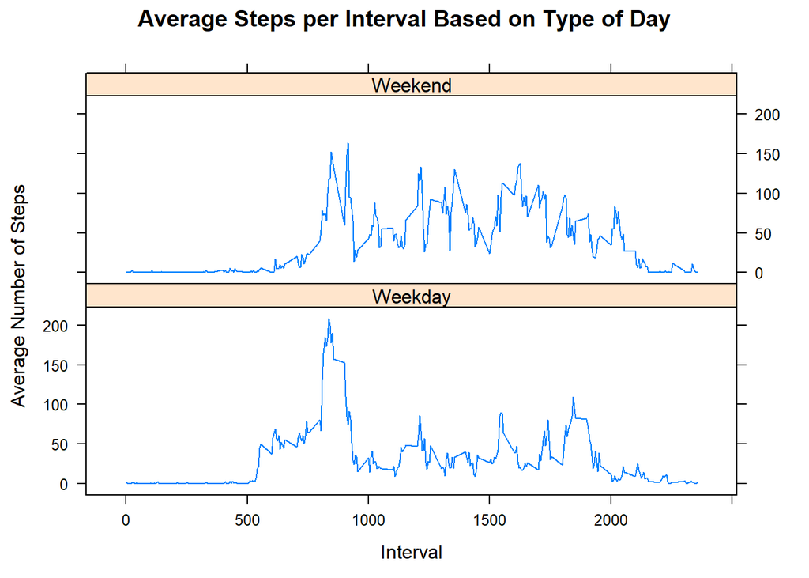

```r
library(lattice)

intTable2 <- ddply(mergeData, .(interval, DayType), summarize, Avg = mean(steps))

## Plot data
xyplot(Avg~interval|DayType, data = intTable2, type = "l", layout = c(1,2), main = "Average Steps per Interval Based on Type of Day", ylab= "Average Number of Steps", xlab= "Interval")
```

The step activity trends are shown in the plot.